# Lecture 28

May 4th, 2016

## Recall: Figure Skating Scores

In Lec27 we studied the relationship between Short and Free program figure skating scores:

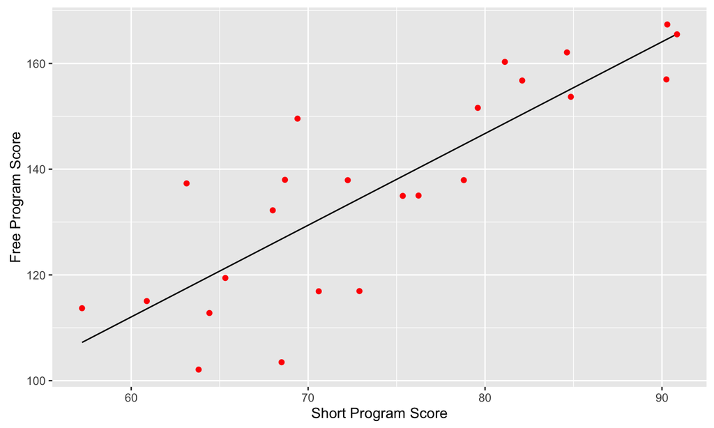

## Regression Table for Skating

Regression output for all software looks something like this:

```
##             Estimate Std. Error t value Pr(>|t|)
## (Intercept)   7.9691    18.1175   0.440    0.664
## Short         1.7347     0.2424   7.157 3.56e-07 ***
##
## Residual standard error: 11.36 on 22 degrees of freedom
## Multiple R-squared:  0.6995, Adjusted R-squared:  0.6859
## F-statistic: 51.22 on 1 and 22 DF,  p-value: 3.562e-07
```

## Bootstrap Regression

Now let's say the population isn't these 24 skaters, but that these 24 skaters are a sample from a hypothetical population of **potential olympic men's figure skaters**.

We

1. Bootstrap resample 24 skaters with replacement
2. Compute the least-squares line
3. Repeat 1. and 2. 30 times

## Bootstrap Regression

We now have 30 bootstrapped regression lines:

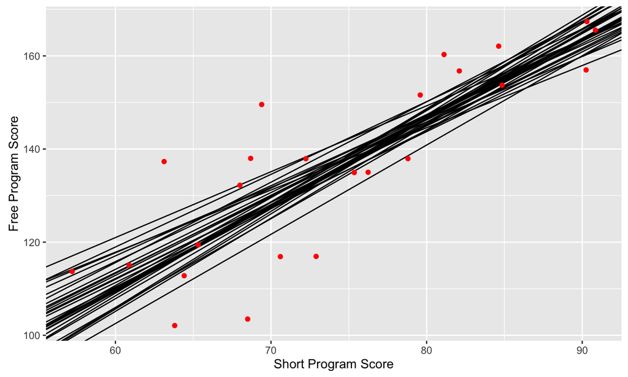

## Bootstrap Intercepts & Slopes

Let's get a better look at the intercepts and slopes by extending the ranges on both axes.

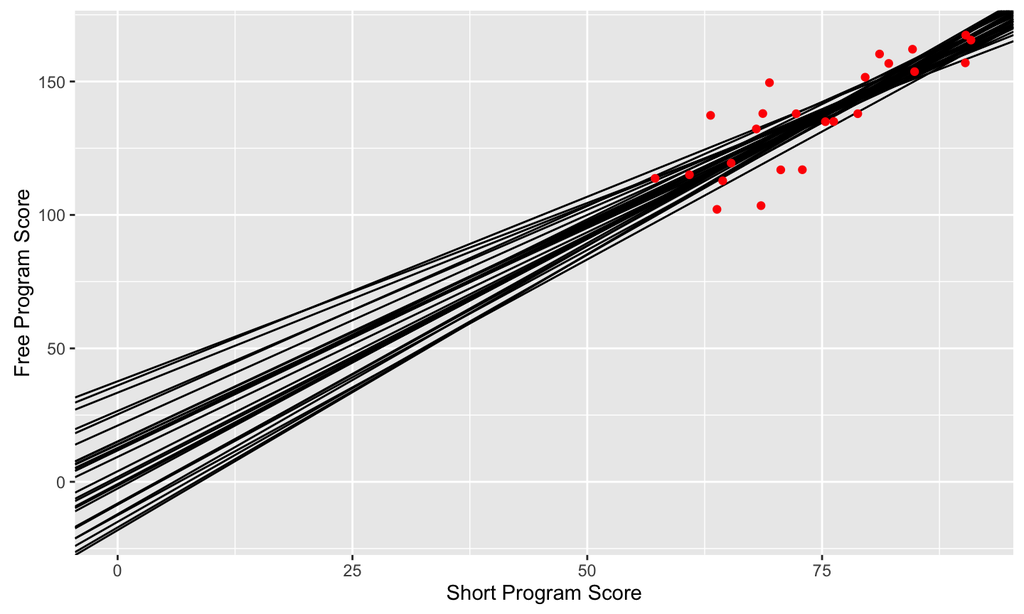

## Example: Bootstrap Intercepts

Histogram of intercepts: the standard deviation i.e the SE is 15.814.

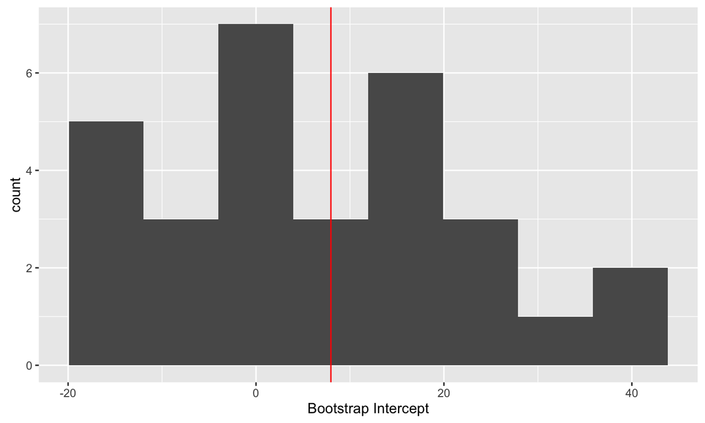

## Example: Bootstrap Slopes

Histogram of slopes: the standard deviation i.e the SE is 0.195.

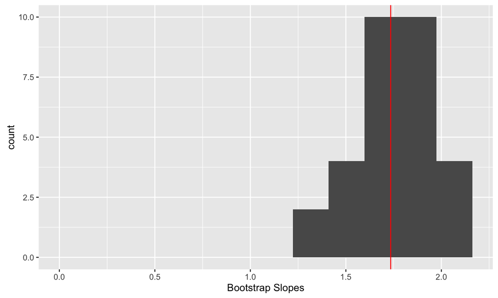

## Permutation Test

We can test if there is a relationship between Short and Free program scores.

i.e.

\[ \begin{align} &H_0: \text{Short and Free are unrelated}\\ \text{vs.} &H_A: \text{Short and Free are related} \end{align} \]

## Permutation Test

Under \(H_0\) Short and Free are unrelated, so we can take the original data:

| Short | Free |
| --- | --- |
| 90.30 | 167.37 |
| 90.85 | 165.51 |
| 90.25 | 156.98 |

## Permutation Test

and permute the rows to no effect.

| Short | Free |
| --- | --- |
| 90.25 | 156.98 |
| 90.30 | 167.37 |
| 90.85 | 165.51 |

## Permutation Test

Just like the permutation test before:

```r
# Data
Short <- Skating2010$Short
Free <- Skating2010$Free
n <- nrow(Skating2010)

# Compute observed correlation coefficient and slope
r <- cor(Free, Short)
model <- lm(Free~Short)
b <- coef(model)[2]
```

## Permutation Test

We **resample without replacement** to permute/reshuffle the pairs of observations:

```r
N <- 10^4
perm_r <- rep(0, N)
perm_b <- rep(0, N)

for(i in 1:N){
  index <- sample(1:n, n, replace = FALSE)
  perm_r[i] <- cor(Free, Short[index])

  perm_model <- lm(Free~Short[index])
  perm_b[i] <- coef(perm_model)[2]
}
```

## Permutation Test

The observed correlation coefficient and slope are in red. The (two-sided) p-values, are both very small.

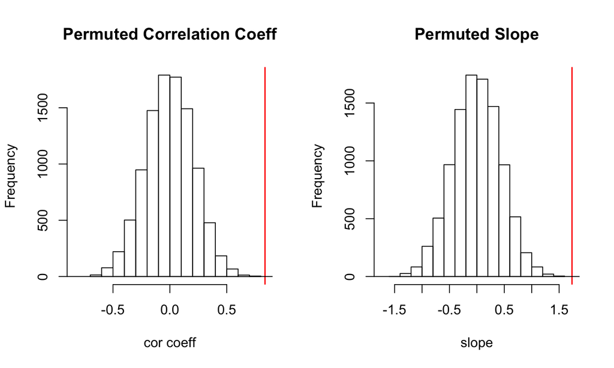